# **Final Project: R Reference Guide**

### **boxplot()**

The “boxplot()” function creates a box-and-whisker plot from a specified data set.

> boxplot(x, …)

##### **Example**

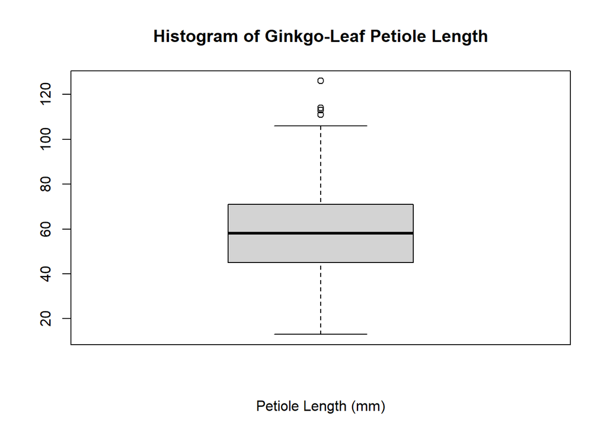

```r
boxplot(ginkgo$petiole_length, xlab = "Petiole Length (mm)", main = "Histogram of Ginkgo-Leaf Petiole Length")
```

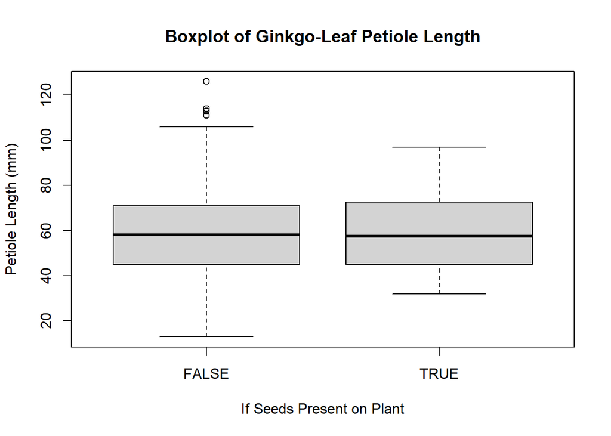

```r
boxplot(ginkgo$petiole_length ~ ginkgo$seeds_present, xlab = "If Seeds Present on Plant", ylab = "Petiole Length (mm)", main = "Boxplot of Ginkgo-Leaf Petiole Length")
```

### **par()**

“par()” is a function used to set graphical parameters. It is often used in conjunction with “mfrow =” and, optionally, “mar =” (margin dimensions c(x,y,z,a)) to display multiple plots in a common view.

##### **mfrow =**

“mfrow =” is a parameter of “par()” that designates the vertical and horizontal allowance for number of plots within a single view. It implements the “c()” function to set a two-dimensional grid, formatted as:

> mfrow = c([horizontal dimensions],[vertical dimensions])

##### **Example**

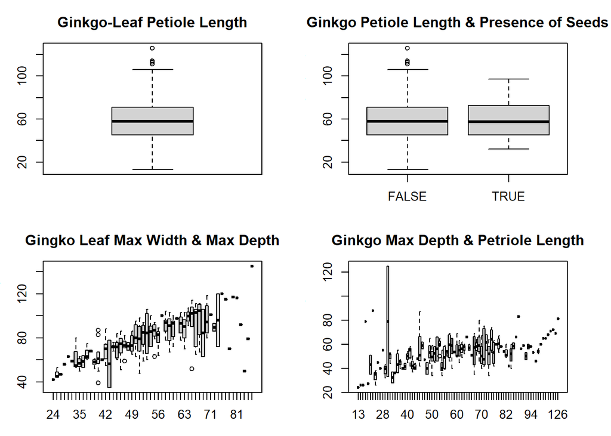

```r
par(mfrow = c(2, 2), mar = c(3, 3, 3, 3))

boxplot(ginkgo$petiole_length, xlab = "Petiole Length (mm)", main = "Ginkgo-Leaf Petiole Length")

boxplot(ginkgo$petiole_length ~ ginkgo$seeds_present, xlab = "If Seeds Present on Plant", ylab = "Petiole Length (mm)", main = "Ginkgo Petiole Length & Presence of Seeds")

boxplot(ginkgo$max_width ~ ginkgo$max_depth, xlab = "Maximum Leaf Width", ylab = "Maximum Leaf Depth", main = "Gingko Leaf Max Width & Max Depth")

boxplot(ginkgo$max_depth ~ ginkgo$petiole_length, xlab = "Maximum Leaf Depth", ylab = "Petiole Length", main = "Ginkgo Max Depth & Petriole Length")
```

back to top :)

## Distribution Functions

### **dnorm()**

The function “dnorm()” calculates the probability density of the normal distribution. It requires a random variable *x*, a population mean, and a population standard deviation.

> dnorm(x, mean = 0, sd = 1, log = FALSE)

##### **Example**

```r
x_dnorm = seq(1, 19, length.out = 100)
y_dnorm = dnorm(x_dnorm, mean = 10.4, sd = 2.4)
y_dnorm
```

```
##   [1] 7.755322e-05 1.040438e-04 1.387842e-04 1.840651e-04 2.427226e-04
##   [6] 3.182414e-04 4.148685e-04 5.377393e-04 6.930118e-04 8.880082e-04
##  [11] 1.131360e-03 1.433151e-03 1.805057e-03 2.260462e-03 2.814563e-03
##  [16] 3.484434e-03 4.289049e-03 5.249250e-03 6.387648e-03 7.728447e-03
##  [21] 9.297174e-03 1.112032e-02 1.322485e-02 1.563767e-02 1.838488e-02
##  [26] 2.149102e-02 2.497818e-02 2.886502e-02 3.316581e-02 3.788932e-02
##  [31] 4.303784e-02 4.860619e-02 5.458084e-02 6.093915e-02 6.764879e-02
##  [36] 7.466742e-02 8.194260e-02 8.941201e-02 9.700396e-02 1.046383e-01
##  [41] 1.122275e-01 1.196783e-01 1.268933e-01 1.337734e-01 1.402195e-01
##  [46] 1.461351e-01 1.514286e-01 1.560160e-01 1.598224e-01 1.627847e-01
##  [51] 1.648531e-01 1.659924e-01 1.661830e-01 1.654218e-01 1.637217e-01
##  [56] 1.611117e-01 1.576361e-01 1.533527e-01 1.483321e-01 1.426547e-01
##  [61] 1.364094e-01 1.296912e-01 1.225981e-01 1.152298e-01 1.076845e-01
##  [66] 1.000574e-01 9.243840e-02 8.491087e-02 7.754998e-02 7.042187e-02
##  [71] 6.358299e-02 5.707971e-02 5.094835e-02 4.521536e-02 3.989784e-02
##  [76] 3.500420e-02 3.053504e-02 2.648404e-02 2.283903e-02 1.958296e-02
##  [81] 1.669501e-02 1.415150e-02 1.192685e-02 9.994396e-03 8.327120e-03
##  [86] 6.898276e-03 5.681903e-03 4.653231e-03 3.788984e-03 3.067599e-03
##  [91] 2.469345e-03 1.976389e-03 1.572790e-03 1.244447e-03 9.790155e-04
##  [96] 7.657910e-04 5.955777e-04 4.605472e-04 3.540929e-04 2.706873e-04
```

### **pnorm()**

The “pnorm()” function calculates the cumulative density of a normal distribution. It requires a random variable *q*, mean, standard deviation value. It can also contain an argument designating whether the lower.tail is true or false.

> pnorm(q, mean = 0, sd = 1, lower.tail = TRUE, log.p = FALSE)

##### **Example**

```r
pnorm(75, mean = 33.2, sd = 2,lower.tail = FALSE)
```

```
## [1] 2.677249e-97
```

### **qnorm()**

The “qnorm()” function calculates the inverse of cumulative density on a normal distribution. It requires a random variable *q*, mean, standard deviation value. It can also contain an argument designating whether the lower.tail is true or false.

> qnorm(p, mean = 0, sd = 1, lower.tail = TRUE, log.p = FALSE)

##### **Example**

```r
qnorm(0.3, mean = 11, sd = 1,lower.tail = TRUE)
```

```
## [1] 10.4756
```

### **dbinom()**

> dbinom(x, size, prob, log = FALSE)

##### **Example**

```r
dbinom(x = 22, size = 60, prob = 0.5)
```

```
## [1] 0.01227688
```

### **pbinom()**

The “pbinom()” function performs a cumulative density analysis on a binomial distribution. It requires a random variable *q*, size (number of trials), and a probability of success between each trial.It can also contain an argument designating whether the lower.tail is true or false.

> pbinom(q, size, prob, lower.tail = TRUE, log.p = FALSE)

##### **Example**

```r
x_pbinom = seq(0, 20, length.out = 30)
pbinom(x_pbinom, size = 40, prob = 0.8)
```

```
##  [1] 1.099512e-28 1.099512e-28 1.770214e-26 1.389893e-24 1.389893e-24
##  [6] 7.091421e-23 2.643314e-21 2.643314e-21 7.672843e-20 1.805381e-18
## [11] 1.805381e-18 3.539063e-17 5.895473e-16 5.895473e-16 8.470886e-15
## [16] 1.061995e-13 1.172330e-12 1.172330e-12 1.147826e-11 1.002678e-10
## [21] 1.002678e-10 7.852154e-10 5.534186e-09 5.534186e-09 3.521525e-08
## [26] 2.028260e-07 2.028260e-07 1.059503e-06 5.027270e-06 2.169189e-05
```

### **qbinom()**

The “qbinom()” function performs an inverse of the cumulative density analysis on a binomial distribution. It requires a random variable *q*, size (number of trials), and a probability of success between each trial.It can also contain an argument designating whether the lower.tail is true or false.

> qbinom(p, size, prob, lower.tail = TRUE, log.p = FALSE)

##### **Example**

```r
x_qbinom = seq(0, 1, length.out = 25)
qbinom(x_qbinom, size = 40, prob = 0.5)
```

```
##  [1]  0 15 16 16 17 17 18 18 19 19 19 20 20 20 21 21 21 22 22 23 23 24 24 25 40
```

back to top :)